# Homework 5

Bingying Liu

February 25, 2020

### Question 1

#### Part(a): Estimate the MLE of $(\theta,\Sigma)$. Make two contour plots, one using the true values of $(\theta,\Sigma)$, and the other using the MLEs. Comment on the differences, if any.

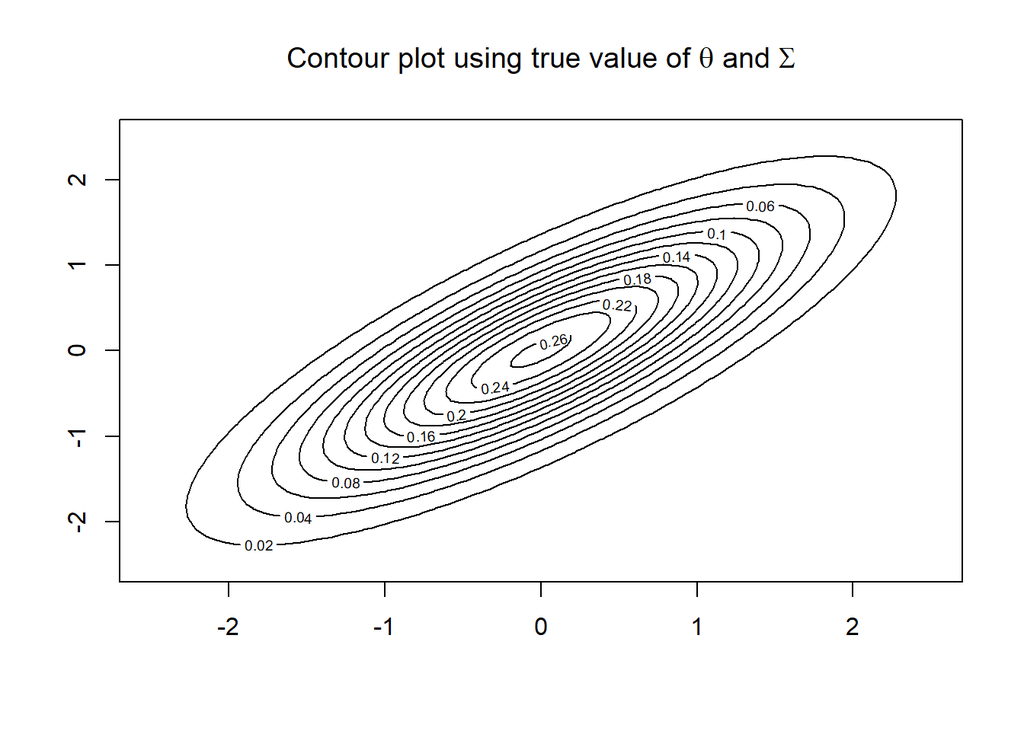

```r
## Simulate data
n = 100
set.seed(1234)
theta = c(0,0)
sigma = matrix(c(1,0.8,0.8,1),nrow=2,ncol=2)
Y = rmvnorm(n, mean = theta, sigma= sigma)

## true value
x.points <- seq(-2.5,2.5,length.out=100)
y.points <- x.points
z <- matrix(0,nrow=100,ncol=100)
for (i in 1:100) {
  for (j in 1:100) {
    z[i,j] <- dmvnorm(c(x.points[i],y.points[j]),
                      mean=theta,sigma=sigma)
  }
}
contour(x.points,y.points,z, main= expression(paste('Contour plot using true value of ',theta, ' and ',Sigma)))
```

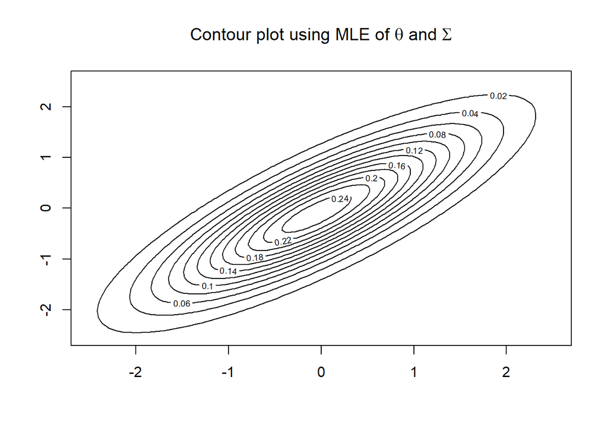

```r
## MLE
theta_MLE = apply(Y,2,mean)
sigma_MLE = t(Y-theta_MLE)%*%(Y-theta_MLE)/n

x.points <- seq(-2.5,2.5,length.out=100)
y.points <- x.points
z <- matrix(0,nrow=100,ncol=100)
for (i in 1:100) {
  for (j in 1:100) {
    z[i,j] <- dmvnorm(c(x.points[i],y.points[j]),
                      mean=theta_MLE,sigma=sigma_MLE)
  }
}
contour(x.points,y.points,z, main= expression(paste('Contour plot using MLE of ',theta, ' and ',Sigma)))
```

There is not much difference between true value of $(\theta, \Sigma)$ and MLE of $(\theta, \Sigma)$ since sample size is big enough for MLE to approximate the true values.

#### Part(b): Assuming independent normal & inverse-Wishart priors for $\theta$ and $\Sigma$, that is, π(θ,Σ)=π(θ)π(Σ), run Gibbs sampler (hyperparameters up to you but you must justify your choices) to generate posterior samples for $(\theta, \Sigma)$.

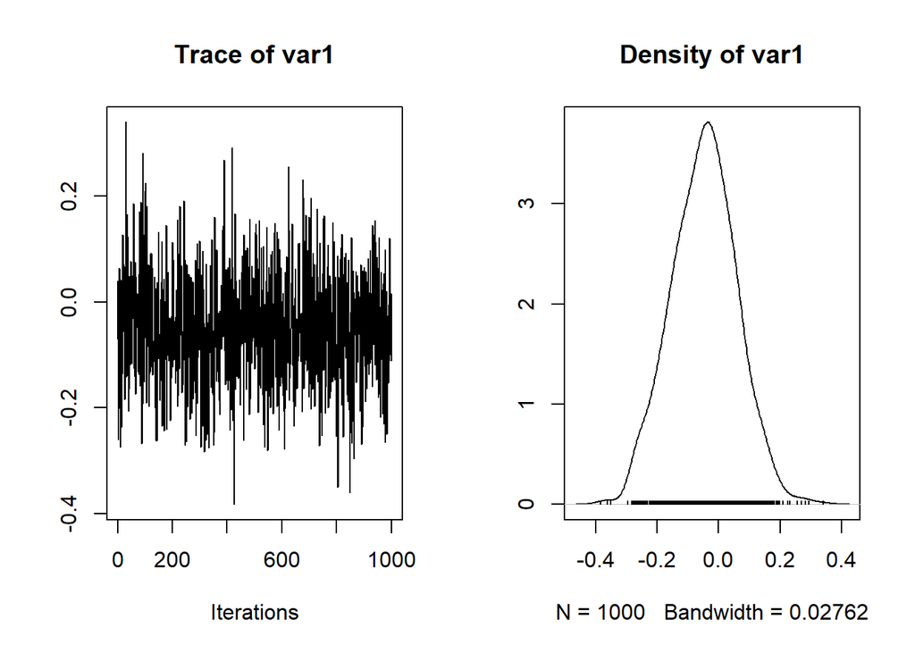

```r
gibbs_normal = function(mu_0, Lambda_0, nu_0, S_0, n_iter, Y){
  n = nrow(Y)
  ybar = apply(Y,2,mean)

  # initial values for Gibbs sampler
  Sigma <- cov(Y)
  # set null matrices to save samples
  THETA <- SIGMA <- NULL

  # first set number of iterations and burn-in, then set seed
  burn_in <- 0.3*n_iter
  set.seed(1234)

  for (s in 1:(n_iter+burn_in)){
    # update theta using its full conditional
    Lambda_n <- solve(solve(Lambda_0) + n*solve(Sigma))
    mu_n <- Lambda_n %*% (solve(Lambda_0)%*%mu_0 + n*solve(Sigma)%*%ybar)
    theta <- rmvnorm(1,mu_n,Lambda_n)
    # update Sigma
    S_theta <- (t(Y)-c(theta))%*%t(t(Y)-c(theta))
    S_n <- S_0 + S_theta
    nu_n <- nu_0 + n
    Sigma <- riwish(nu_n, S_n)
    # save results only past burn-in
    if(s > burn_in){
      THETA <- rbind(THETA,theta)
      SIGMA <- rbind(SIGMA,c(Sigma))
    }
  }
  colnames(THETA) <- c("theta_1","theta_2")
  colnames(SIGMA) <- c("sigma_11","sigma_12","sigma_21","sigma_22") #symmetry in sigma

  return(list(theta = THETA, sigma = SIGMA))
}

# Initialize the hyperparameters
ybar = apply(Y,2,mean)
mu_0 = c(0,0)
Lambda_0 = matrix(c(1,0.5,0.5,1),nrow=2, ncol=2)
nu_0 = 4
S_0 =  matrix(c(1,0,0,1),nrow=2, ncol=2)

# Performs Gibbs Sampling
normal_mcmc = gibbs_normal(mu_0, Lambda_0, nu_0, S_0, n_iter=1000, Y=Y)

# Diagnostics check (autocorrelation plot seems reasonable)
THETA.mcmc <- mcmc(normal_mcmc$theta,start=1);
plot(THETA.mcmc[,"theta_1"])
```

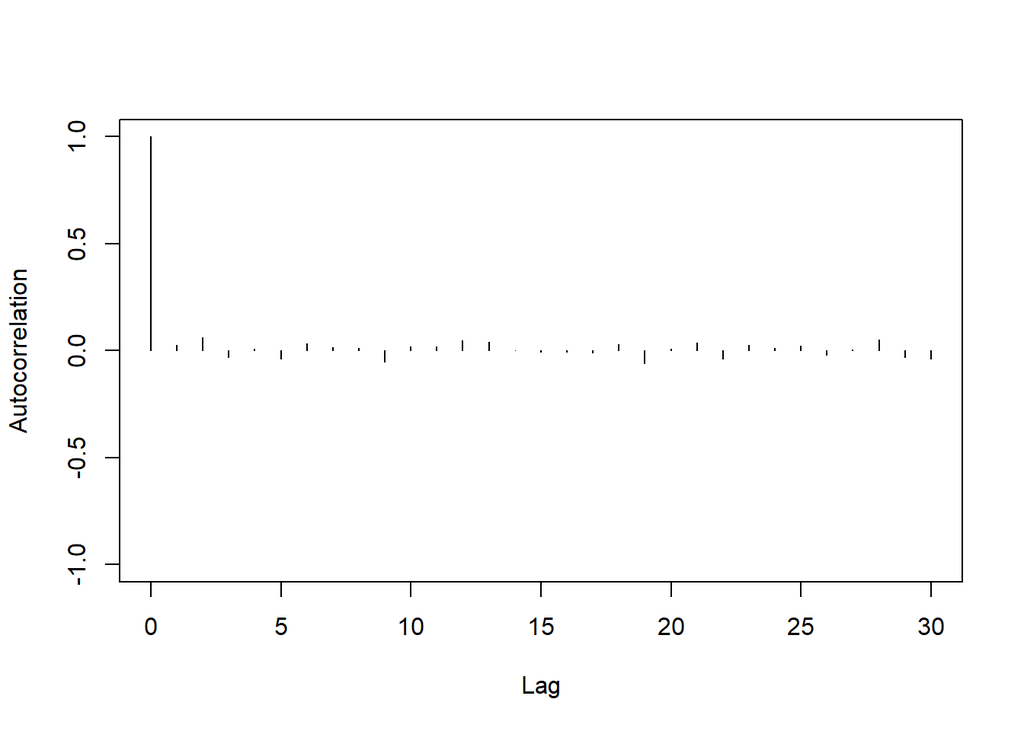

```r
autocorr.plot(THETA.mcmc[,"theta_1"])
```

#### Part(c): Compare Bayes estimates of $(\theta, \Sigma)$ to MLE and truth. Comment on the similarities and differences. How much influence do you think your prior had on the Bayes estimates in particular?

```r
# THETA
apply(normal_mcmc$theta, 2, mean); # Bayes estimate
```

```
##     theta_1     theta_2
## -0.04776418 -0.09744347
```

```r
theta_MLE; # MLE
```

```
## [1] -0.05010387 -0.10488054
```

```r
theta # truth
```

```
## [1] 0 0
```

```r
# SIGMA
apply(normal_mcmc$sigma, 2, mean) # Bayes estimae
```

```
##  sigma_11  sigma_12  sigma_21  sigma_22
## 1.0982339 0.8893127 0.8893127 1.0896247
```

```r
sigma_MLE # MLE
```

```
##           [,1]      [,2]
## [1,] 1.0978773 0.8933898
## [2,] 0.8933898 1.0792508
```

```r
sigma # truth
```

```
##      [,1] [,2]
## [1,]  1.0  0.8
## [2,]  0.8  1.0
```

Since MLE is very close the true value of $(\theta, \Sigma)$ and also since we’re using a diffuse/non-informative prior, prior is drown out by data. In this case, I calculated the expectation of Bayes estimate of $\theta$ and $\Sigma$. Both of the expectations are very close to MLE values, which shows that it’s data that dominates the expected value of Bayes estimates. My prior had little influence on Bayes estimate.

#### Part(d): Given $y_{i2}$ values for 50 new (test) subjects, describe in as much detail as possible, how you would use the Gibbs sampler to predict new $y_{i1}$ values, given the $y_{i2}$ values, from the “conditional posterior predictive distribution” of $(y_{i1}|y_{i2})$.

For each iteration s:  
- We use Gibbs sampler to sample one $\theta$ and one $\Sigma$ from posterior distribution $p(\theta, \Sigma|y_{1:100})$.  
- We derive $p(y_{i1}^{101:150} | y_{i2}^{101:150}, \theta, \Sigma)$ by putting the sampled $\theta$ and $\Sigma$ into conditional distribution $Y_1|(Y_2 = y_2) \sim N(\theta_1 + \Sigma_{12} \Sigma_{22}^{-1} (y_2-\theta_2), \Sigma_{11}- \Sigma_{12}\Sigma_{22}^{-1}\Sigma_{21})$.

Repeat the process for n_iter.

### Question 2: Hoff 7.4

#### a) Before you look at the data, use your own knowledge to formulate a semiconjugate prior distribution for $\theta = (\theta_h, \theta_w)^T$ and $\Sigma$, where $\theta_h$, $\theta_w$ are mean husband and wife ages, and $\Sigma$ is the covariance matrix.

Considering the life expectancy and marriage age, I think most ages will fall between $(25,85)$. The average age of women might be higher than men, but I don’t have scientific proof to support it. It seems intuitive that there are less married couples at age 25 and 85 than there are married couples around 55 ($\frac{25+85}{2}$). So the bell curve centers around 55 with variance $(\frac{55-25}{2})^2 = 225$ such that approximately 95% of my prior falls within range $(25,85)$. I also believe the age of married coupes are close to each other, with a correlation if 0.8, which results in the covariance to be $225*0.8 = 180$. Thus the prior covariance matrix for $\theta$ is $\Lambda_0 = \left[\begin{matrix}225 & 180 \\ 180 & 225\end{matrix}\right]$.  
For variance $\Sigma$, the same logic of the ranges of ages still applies here. I’ll set $S_0 = \Sigma_0$, but make $\Sigma$ only loosely centered around $\Sigma_0$ by setting $\nu_0=p+2=4$.

#### b) Generate a prior predictive dataset of size n = 100, by sampling $(\theta,\Sigma)$ from your prior distribution and then simulating $Y_1,...,Y_n \sim$ i.i.d multivariate normal $(\theta, \Sigma)$. Generate several such datasets, make bivariate scatterplots for each dataset, and make sure they roughly represent your prior beliefs about what such a dataset would actually look like.

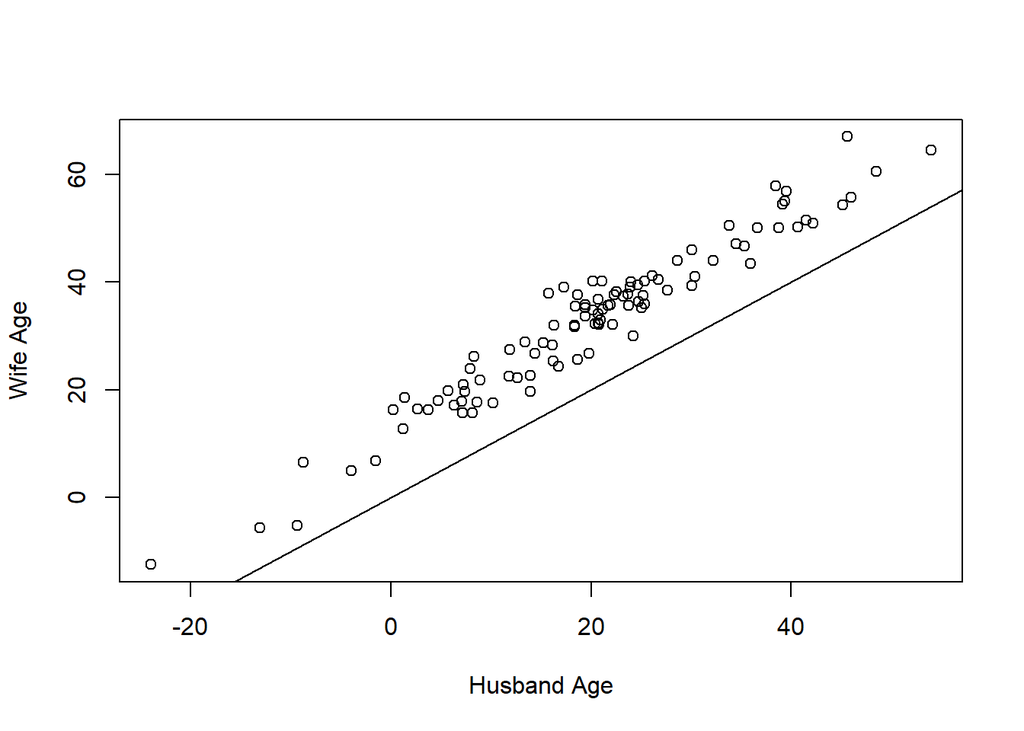

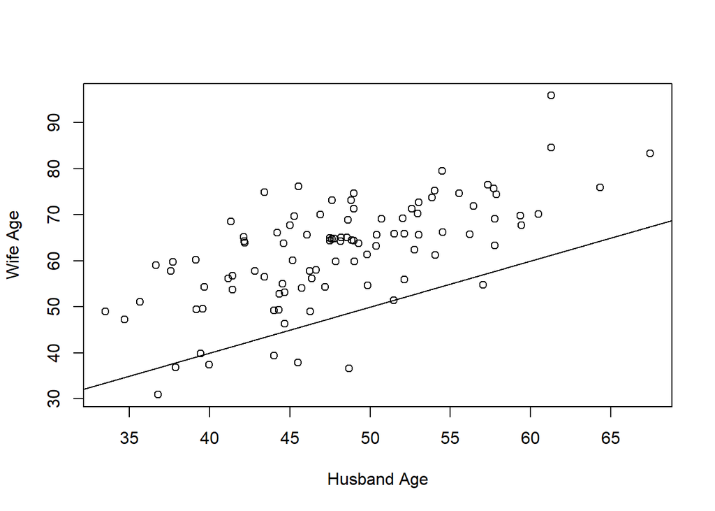

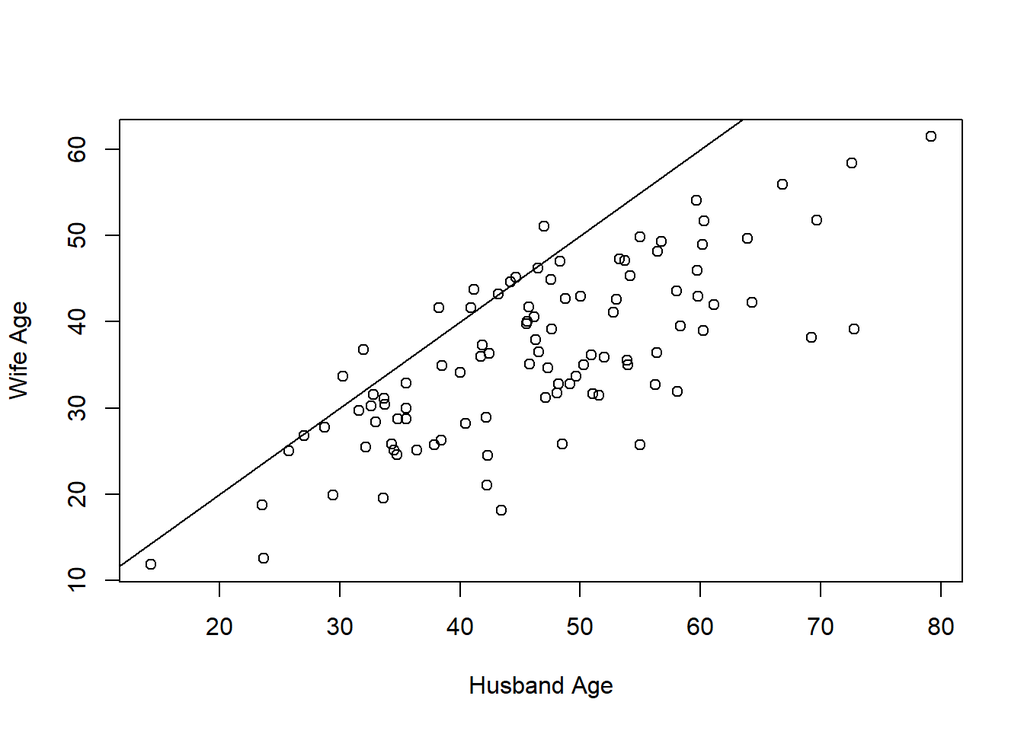

```r
n = 100
m = 15 # number of datasets

mu_0 = c(55,55)
Lambda_0 = matrix(c(225,180,180,225),nrow=2, ncol=2)
nu_0 = 4
S_0 =  Lambda_0

# Set null matrices to save samples
THETA <- SIGMA <- Y.prior <- NULL

for (i in 1:m){
  # sample
  theta = rmvnorm(1, mu_0, Lambda_0)
  Sigma = riwish(nu_0, S_0)
  Y = rmvnorm(n, theta, Sigma)

  # generate
  THETA <- rbind(THETA,theta)
  SIGMA <- rbind(SIGMA,c(Sigma))
  Y.prior <- rbind(Y.prior,c(Y))
}

# Plotting, visual check
ids = sample(1:m, 3)
for (id in ids){
  plot(Y.prior[id, 1:100], Y.prior[id, 101:200], xlab = 'Husband Age', ylab = 'Wife Age')
  abline(a=0, b=1)
}
```

#### c) Using you prior distribution and the 100 values in the dataset, obtain an MCMC approximation to $p(\theta,\Sigma|y_1,...,y_100)$. Plot the joint posterior distribution of $\theta_h$ and $\theta_w$, and also the marginal osterior density of the correlation between $Y_h$ and $Y_w$, the ages of a husband and wife. Obtain 95% posterior confidence intervals for $\theta_h$ and $\theta_w$ and the correlation coefficient.

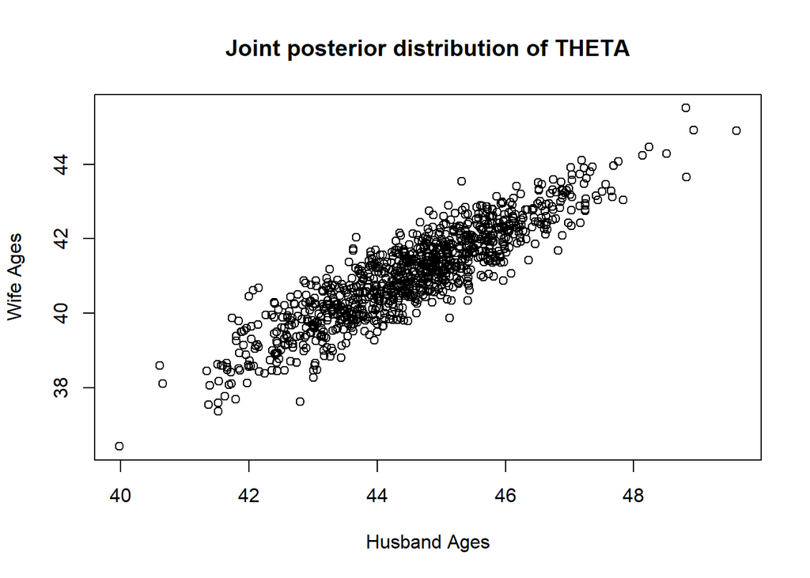

```r
# Read in data
age = read.table('agehw.dat', header = TRUE)

# Hyperparameters for the priors
mu_0 = c(55,55)
Lambda_0 = matrix(c(225,180,180,225),nrow=2, ncol=2)
nu_0 = 4
S_0 =  Lambda_0

# Gibbs Sampler
normal_age_mcmc = gibbs_normal(mu_0, Lambda_0, nu_0, S_0, n_iter=1000, Y=age)

# Plots
plot(normal_age_mcmc$theta[,"theta_1"], normal_age_mcmc$theta[,"theta_2"], xlab="Husband Ages", ylab="Wife Ages", main = "Joint posterior distribution of THETA")
```

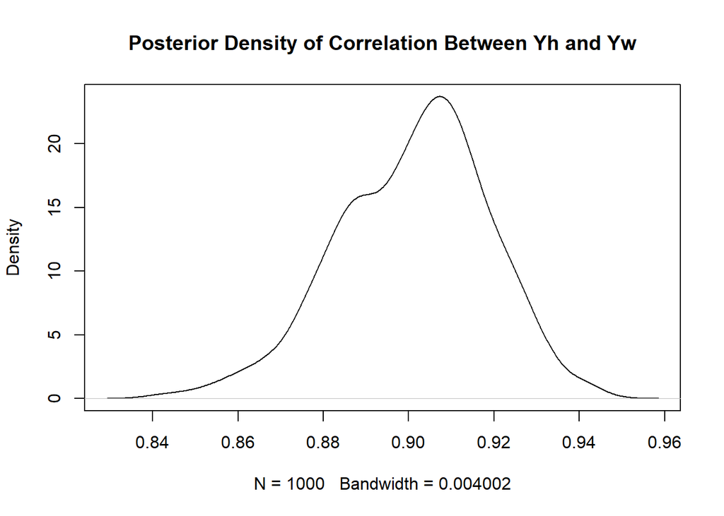

```r
CORR = normal_age_mcmc$sigma[,2]/sqrt((normal_age_mcmc$sigma[, 1]* normal_age_mcmc$sigma[, 4]))
plot(density(CORR), main = "Posterior Density of Correlation Between Yh and Yw")
```

```r
# 95% posterior confidence intervals for THETA and correlation coefficient
quantile(normal_age_mcmc$theta[,"theta_1"], probs = c(0.025,0.975))
```

```
##     2.5%    97.5%
## 41.85173 47.22440
```

```r
quantile(normal_age_mcmc$theta[,"theta_2"], probs = c(0.025,0.975))
```

```
##     2.5%    97.5%
## 38.50918 43.41570
```

```r
quantile(CORR, probs = c(0.025,0.975))
```

```
##      2.5%     97.5%
## 0.8634539 0.9318348
```